# R Workshop - Introduction and ecological applications

## Summary

#### 1. Basics

- The R environment
- Creating a new project
- R as a calculator
- Scripts
- Important details
- Definition of some important symbols
- Functions
- Removing objects from workspace
- Packages
- Help
- Data classes
- Main type of objects

#### 2. Creation and manipulation of data

- Creating vectors
- Operations with vectors
- Creating matrices and dataframes
- Importing and exporting data with R
- Visualizing dataframes
- Operations with dataframes

#### 3. Plots

- Scatterplots
- Boxplots
- Barplots
- Histograms and kernel density estimation plots
- Pie charts
- Plots to explore multicollinearity in the database
- 2D plots with three variables
- Multiple panels in a single plot area

#### 4. Statistics

- Linear regression
- Multiple regression
- T-test and paired T-test
- Analysis of Variance (ANOVA)
- Generalized Linear Models (GLM)
- Generalized Least Squares (GLS)
- Mixed model
- Model selection and cross validation
- Rarefaction
- Multivariate analysis of variance (MANOVA)
- Clusters
- Unconstrained ordinations
- Constrained ordinations
- Occupancy modeling
- Species distribution modeling

## 1. Basics

### The R environment

In this workshop we are going to work with R studio which is an integrated development environment (IDE) for R. By clicking on the R studio icon in your desktop, a window like the one below should pop up.

[figure not shown]

**Menu items**: Several options for the user are available in this menu bar, including save and load projects and scripts (File tab), change font size and background color (Tools>Global Option), and set work directory (Session).

**Workspace:** Shows you the objects (e.g., tables, dataframes, arrays, function, etc) saved in your working directory. If you click on the History tab, you can access all your recent commands to the program.

**R console:** This is the place where the program is waiting for you to tell it what to do. You can type commands directly in this window and type enter to confirm. However, the commands are lost when you close the session. In order to avoid this problem, you can save all your commands on a script file (see section 4), which works similarly to a note pad. The symbol “>” means that the R console is ready to receive your next command. On the other hand, the symbol “+” indicates that the command typed is not complete. The keyboard key “Escape” (esc) cancel an incomplete command.

**Files, Plots, Packages, Help, Viewer:** On this window you can choose among 5 different options. The tab file shows you all files that were saved in the current directory. The tab file allows you to see plots that are created by the user via commands in the R console. The tab packages bring a list of all packages installed in your computer and shows you which of them are currently loaded. On the tab Help, the user can search for support regarding the use of specific functions, packages and even analysis. Finally, the tab viewer is a new option that is used to view local web content.

Return to the Summary

### Creating a new project

You can create a new project in R clicking on the File tab and then selecting **New project> New Directory> Empty project> Create project**. To check the working directory where all your saved files are being stored, use the function:

```r
getwd()
```

'C:/Users/FriedrichWolfgang/Documents/wolfgang/Trabalhos/R_workshop'

You can set your working directory in R using the function “setwd”, for example:

```r
setwd ("C:/Users/FriedrichWolfgang/Desktop/Workshop/R")
```

Return to the Summary

### R as a calculator

R can be used as a calculator. Let’s start typing the formulas below.

```r
1+2+3
```

6

```r
2*6
```

12

```r
(2+3)/2
```

2.5

```r
(2^2)+3
```

7

Return to the Summary

### Scripts

Instead of typing all commands on the R console every time you open R, it is practical to use a script, which is a simple text document that is readable in R. To open a new script, select **File>New File>R script**. To save the script, select **File>Save**, or just click on the save button (looks like a floppy disk).

To run a code from the script window, you have to press CTRL + Enter together. The commands are run line by line. To run multiple lines at the same time, you have to select all the lines that you want and then press CTRL + Enter.

Return to the Summary

### Important details

- R is case sensitive (A ≠ a).
- Do not use spaces in names of objects.
- Do not start object names with numbers or special symbols (e.g., @, /, #).
- Do not forget to close parentheses, quotation marks and brackets that are open.

Return to the Summary

### Definition of some important symbols

Objects are assigned using the symbol “<-“ or the symbol “=”. I suggest you to always use the symbol “<-“. To call the object, just write the object name and press CTRL + Enter. For example:

```r
object_name <- 1+2
object_name
```

3

The hashtag symbol (#) tells R that all things wrote after this symbol are a text and not a command. This is very useful because allow us to write notes in the middle of the code. For example:

```r
1+2 # The result of this equation is three
```

3

Use single or double quotes to tell R to interpret something as a string. See below.

```r
first_animal <- "fish"
second_animal <- 'cat'
```

Commas (,) separate arguments in a function.

```r
rep (10, 5) # Repeat the number 10 (first argument) five times (second argument)
```

1. 10

2. 10

3. 10

4. 10

5. 10

Relational operators: “>” means greater than; “<” means lower than; “==” means equal to; “<=” means equal or lower than; “>=” means equal or larger than; “!=” means different from. For example:

```r
a <- 1
b <- 10
```

```r
a > b
```

FALSE

```r
a == b
```

FALSE

```r
a != b
```

TRUE

Question mark (?) is used to access the documentation (help) of functions, symbols and packages. You can also use two question marks together (??) to search for specific subjects in the R Help System. This is useful when we don’t know the specific name of the function. We are going to talk more about this on section 8. See an example below.

```r
?sum
```

| sum {base} | R Documentation |
| --- | --- |

Sum of Vector Elements

Description

`sum` returns the sum of all the values present in its arguments.

Usage

```
sum(..., na.rm = FALSE)
```

Arguments

| `...` | numeric or complex or logical vectors. |
| --- | --- |
| `na.rm` | logical. Should missing values (including `NaN`) be removed? |

Details

This is a generic function: methods can be defined for it directly or via the `Summary` group generic. For this to work properly, the arguments `...` should be unnamed, and dispatch is on the first argument.

If `na.rm` is `FALSE` an `NA` or `NaN` value in any of the arguments will cause a value of `NA` or `NaN` to be returned, otherwise `NA` and `NaN` values are ignored.

Logical true values are regarded as one, false values as zero. For historical reasons, `NULL` is accepted and treated as if it were `integer(0)`.

Loss of accuracy can occur when summing values of different signs: this can even occur for sufficiently long integer inputs if the partial sums would cause integer overflow. Where possible extended-precision accumulators are used, typically well supported with C99 and newer, but possibly platform-dependent.

Value

The sum. If all of the *M* `...` arguments are of type integer or logical, then the sum is `integer` when possible and is `double` otherwise. Integer overflow should no longer happen since **R** version 3.5.0. For other argument types it is a length-one numeric (`double`) or complex vector.

**NB:** the sum of an empty set is zero, by definition.

S4 methods

This is part of the S4 `Summary` group generic. Methods for it must use the signature `x, ..., na.rm`.

‘plotmath’ for the use of `sum` in plot annotation.

References

Becker, R. A., Chambers, J. M. and Wilks, A. R. (1988) *The New S Language*. Wadsworth & Brooks/Cole.

See Also

`colSums` for row and column sums.

Examples

```
## Pass a vector to sum, and it will add the elements together.
sum(1:5)

## Pass several numbers to sum, and it also adds the elements.
sum(1, 2, 3, 4, 5)

## In fact, you can pass vectors into several arguments, and everything gets added.
sum(1:2, 3:5)

## If there are missing values, the sum is unknown, i.e., also missing, ....
sum(1:5, NA)
## ... unless  we exclude missing values explicitly:
sum(1:5, NA, na.rm = TRUE)
```

[Package *base* version 3.6.1 ]

Colon operator “:” generates regular sequences (from:to). For example:

```r
1:5
```

1. 1

2. 2

3. 3

4. 4

5. 5

Colon operators can also used to indicate the interaction between two or more factors in statistical analyses. We are going to learn more about this during the workshop.

The dollar sign ($) is used to extract or replace parts of an object. This is a very useful symbol for handling dataframes and we are going to learn more about it in the next sections. See an example below.

```r
student_scores <- data.frame("Score"=1:10, "Student"=LETTERS[1:10]) #creating dataframe
student_scores$Score
```

1. 1

2. 2

3. 3

4. 4

5. 5

6. 6

7. 7

8. 8

9. 9

10. 10

```r
student_scores$Score <- seq (10,1) #assign new values to the variable "score"
student_scores$Score
```

1. 10

2. 9

3. 8

4. 7

5. 6

6. 5

7. 4

8. 3

9. 2

10. 1

The symbols “|” and “&” are also very used in R and mean “or” and “and”, respectively. For example:

```r
subset(student_scores, Score==10 & Student=="A") #Subset of a dataframe. All cases with scores = 10 and student = A
```

| Score | Student |
| --- | --- |
| 10 | A |

```r
subset(student_scores, Score==1 | Student=="A") #Subset of a dataframe. All cases with scores = 1 or student = J
```

|  | Score | Student |
| --- | --- | --- |
| 1 | 10 | A |
| 10 | 1 | J |

The tilde operator (~) is used to separate the left- and right sides of a model formula. For instance:

```r
y<-1:10
x<-1:10
lm (y~x) # y model by x. This is a linear regression.
```

```
Call:
lm(formula = y ~ x)

Coefficients:
(Intercept)            x
  1.123e-15    1.000e+00
```

Return to the Summary

### Functions

Most of the time, we are going to use functions that were already created by others. This makes our life much easier because we don’t need to write down codes to represent complex mathematical formulas, algorithms or statistical analysis (a very smart person has already done this job for us). Functions are used in the following way: **Function (argument 1, argument 2, argument 3, …)** The number and type of arguments depend on the function you are using. For example:

```r
sum (1,10) # returns the sum of all the values present in its arguments (i.e. 1 and 10)
```

11

```r
sqrt (4) # it calculates the square root of a number or a series of numbers
```

2

```r
log (4) # it calculates the natural logarithm of a number or a series of numbers
```

1.38629436111989

```r
min (1,2,5,0.5) # returns the smaller number of all the values present in its arguments
```

0.5

```r
max (1,2,5,0.5) # returns the larger number of all the values present in its arguments
```

5

```r
mean (1,2,5,0.5) # returns the average of all the values present in its arguments
```

1

```r
range (1,2,5,0.5) # returns the range of all the values present in its arguments
```

1. 0.5

2. 5

```r
prod (1,2,5,0.5) # returns the product of all the values present in its arguments
```

5

We can also create our own functions! This can be done using the function "function'. Lets' create below a function to divide the first element (a) by the second (b) and then multiple by the third (c).

```r
# First we define our function
our_first_function = function (a,b,c){
    ( a / b ) * c
}

# Now let's use it!
our_first_function (2,2,5)
```

5

### Removing objects from workspace

To exclude objects, you can use the function “rm”, see below.

```r
rm (our_first_function)
```

Remove all objects, except "x".

```r
x <- sd (c(1 , 5, 7, 3))
rm(list=setdiff(ls(), c("x")))
```

To remove all object all object, use:

```r
rm(list = ls())
```

Return to the Summary

### Packages

To run some functions, we have to install and load some packages. Packages are units of reproducible R code, that contain functions, documentations that describe how to use these functions, and sample data. Let’s take the package “vegan” as an example. This is a very popular package for multivariate analysis in Ecology. You can install this package clicking on the tab “packages” (inferior left window) and then Install, which should open another window that allow you to search for the packages name. You can also use the function below.

```r
install.packages ("vegan")
```

To load the package, you can use function “require” or “library”. For instance:

```r
require (vegan) # it also works if you run: library (vegan)
```

Don’t forget that you have to be connect with the internet to download the package. Be aware that some incompatibilities between old versions of R and the packages can occur! Try to uninstall the old version of R and install the new one with some regularity (~every three months).

Return to the Summary

### Help

When we are not sure about how to use a specific function or when we don’t know the name of the function that do a specific task, it is a good idea to explore the help documentations that are available in R. To access the R documentation of a specific function, we just have to type question mark followed by the name of the function or use the function “help”. For example:

```r
? seq #it also works if you use: help (seq)
```

| seq {base} | R Documentation |
| --- | --- |

Sequence Generation

Description

Generate regular sequences. `seq` is a standard generic with a default method. `seq.int` is a primitive which can be much faster but has a few restrictions. `seq_along` and `seq_len` are very fast primitives for two common cases.

Usage

```
seq(...)

## Default S3 method:
seq(from = 1, to = 1, by = ((to - from)/(length.out - 1)),
    length.out = NULL, along.with = NULL, ...)

seq.int(from, to, by, length.out, along.with, ...)

seq_along(along.with)
seq_len(length.out)
```

Arguments

| `...` | arguments passed to or from methods. |
| --- | --- |
| `from, to` | the starting and (maximal) end values of the sequence. Of length `1` unless just `from` is supplied as an unnamed argument. |
| `by` | number: increment of the sequence. |
| `length.out` | desired length of the sequence. A non-negative number, which for `seq` and `seq.int` will be rounded up if fractional. |
| `along.with` | take the length from the length of this argument. |

Details

Numerical inputs should all be finite (that is, not infinite, `NaN` or `NA`).

The interpretation of the unnamed arguments of `seq` and `seq.int` is *not* standard, and it is recommended always to name the arguments when programming.

`seq` is generic, and only the default method is described here. Note that it dispatches on the class of the **first** argument irrespective of argument names. This can have unintended consequences if it is called with just one argument intending this to be taken as `along.with`: it is much better to use `seq_along` in that case.

`seq.int` is an internal generic which dispatches on methods for `"seq"` based on the class of the first supplied argument (before argument matching).

Typical usages are

```
seq(from, to)
seq(from, to, by= )
seq(from, to, length.out= )
seq(along.with= )
seq(from)
seq(length.out= )
```

The first form generates the sequence `from, from+/-1, ..., to` (identical to `from:to`).

The second form generates `from, from+by`, ..., up to the sequence value less than or equal to `to`. Specifying

```
to -
  from
```

and `by` of opposite signs is an error. Note that the computed final value can go just beyond `to` to allow for rounding error, but is truncated to `to`. (‘Just beyond’ is by up to *1e-10* times `abs(from - to)`.)

The third generates a sequence of `length.out` equally spaced values from `from` to `to`. (`length.out` is usually abbreviated to `length` or `len`, and `seq_len` is much faster.)

The fourth form generates the integer sequence

```
1, 2, ...,
    length(along.with)
```

. (`along.with` is usually abbreviated to `along`, and `seq_along` is much faster.)

The fifth form generates the sequence `1, 2, ..., length(from)` (as if argument `along.with` had been specified), *unless* the argument is numeric of length 1 when it is interpreted as `1:from` (even for `seq(0)` for compatibility with S). Using either `seq_along` or `seq_len` is much preferred (unless strict S compatibility is essential).

The final form generates the integer sequence

```
1, 2, ...,
  length.out
```

unless `length.out = 0`, when it generates `integer(0)`.

Very small sequences (with `from - to` of the order of *10^{-14}* times the larger of the ends) will return `from`.

For `seq` (only), up to two of `from`, `to` and `by` can be supplied as complex values provided `length.out` or `along.with` is specified. More generally, the default method of `seq` will handle classed objects with methods for the `Math`, `Ops` and `Summary` group generics.

`seq.int`, `seq_along` and `seq_len` are primitive.

Value

`seq.int` and the default method of `seq` for numeric arguments return a vector of type `"integer"` or `"double"`: programmers should not rely on which.

`seq_along` and `seq_len` return an integer vector, unless it is a *long vector* when it will be double.

References

Becker, R. A., Chambers, J. M. and Wilks, A. R. (1988) *The New S Language*. Wadsworth & Brooks/Cole.

See Also

The methods `seq.Date` and `seq.POSIXt`.

`:`, `rep`, `sequence`, `row`, `col`.

Examples

```
seq(0, 1, length.out = 11)
seq(stats::rnorm(20)) # effectively 'along'
seq(1, 9, by = 2)     # matches 'end'
seq(1, 9, by = pi)    # stays below 'end'
seq(1, 6, by = 3)
seq(1.575, 5.125, by = 0.05)
seq(17) # same as 1:17, or even better seq_len(17)
```

[Package *base* version 3.6.1 ]

These R documentations follow a standardize format, which is basically composed of:

- **Description:** Brief description of the function
- **Usage:** How to use the function and the arguments that are required.
- **Arguments:** Description of each argument
- **Details:** Details about the use and application of the function
- **Values:** List and explain the outputs of the function
- **Notes:** Some general notes about the function
- **Authors:** List the authors of the function
- **References:** References used to create the function
- **See also:** Shows other functions that are somehow related with the function searched
- **Examples:** Provides some examples showing the usage of the function.

To search for functions that do some specific tasks, you can use the function “help.search” or “??”. For example:

```r
?? logarithm
```

```
starting httpd help server ... done
```

If you are connected with the internet, you can search the files associated with the word searched in the help files located in the R website. For instance:

```r
RSiteSearch("logarithm")
```

```
A search query has been submitted to http://search.r-project.org
The results page should open in your browser shortly
```

The “R community” is very active, friendly and cooperative. There are many websites, blogs and mailing lists that you can search for help and information from other R users, including:

- stackoverflow https://stackoverflow.com (my favorite)
- R-Bloggers http://www.r-bloggers.com
- Mailing lists https://www.r-project.org/mail.html
- R cookbook http://www.cookbook-r.com
- Youtube https://www.youtube.com/ (many different channels teach how to use R)

Free R manuals can also be found on the internet. On the R website, search for manuals (https://cran.r-project.org/manuals.html). More specific manuals, especially related with statistics and plots, can be found on the website https://cran.r-project.org/other-docs.html.

Return to the Summary

### Data classes

R supports some basic data classes that are useful for us to know:

1. Logical - two possible values (binary) represented by TRUE and FALSE.

```r
logical_object <- TRUE
class (logical_object) # Function that tell us the class of a given object
```

'logical'

1. Numeric – integers (without a fractional component) and float numbers (numbers that are not integers, because it includes a fraction represented in decimal format)

```r
int_num_object <- 5
class (int_num_object)
```

'numeric'

```r
float_num_object <- 5.2
class (float_num_object)
```

'numeric'

1. Character/string – composed of characters (strings), not numbers. Numbers are only used as characters/ strings if they are not going to participate in math equations. Example zip code, phone numbers.

```r
str_obj <- "goat"
class (str_obj)
```

'character'

1. Factor – Data composed of categories that not follow any specific order.

```r
fact_obj <- factor("goat") #factor function is used to create a factor
class (fact_obj)
```

'factor'

1. Ordinal – It is similar to categorical data, but ordinal data has a clear ordering among the different categories.

```r
vec_ord <- c('goat','horse','turtle') #this is a vector. We are going to talk about it in the next sections
ord_obj <- factor (vec_ord, levels = c('goat','horse','turtle'), order = TRUE)
class(ord_obj)
```

1. 'ordered'

2. 'factor'

Return to the Summary

### Main type of objects

In R, everything is an object. However, it is important to specific types. See below some of them.

1. Vectors: Sequence of numeric values, characters or logical elements (TRUE or FALSE).

```r
model_vector = c (1, 2, 3, 4)
is.vector (model_vector) #Test if it is a vector
```

TRUE

```r
print (model_vector) #function to print object
```

```
[1] 1 2 3 4
```

1. Matrices: Set of bi-dimensional vectors (rows and columns) of the same class.

```r
model_matrix = matrix (1:9, nrow = 3, ncol = 3)
is.matrix (model_matrix) #Test if it is a matrix
```

TRUE

```r
print (model_matrix)
```

```
     [,1] [,2] [,3]
[1,]    1    4    7
[2,]    2    5    8
[3,]    3    6    9
```

1. Dataframes: Similar to a matrix, but accept columns of different classes.

```r
model_df = data.frame (x=c(1,2,3),
                       y=c("a","b","c"))
is.data.frame (model_df) #Test if it is a dataframe
```

TRUE

```r
print (model_df)
```

```
  x y
1 1 a
2 2 b
3 3 c
```

1. Lists: Series of objects (vectors, matrices, dataframes).

```r
model_list = list (model_vector, model_matrix, model_df)
is.list (model_list)
```

TRUE

```r
print (model_list)
```

```
[[1]]
[1] 1 2 3 4

[[2]]
     [,1] [,2] [,3]
[1,]    1    4    7
[2,]    2    5    8
[3,]    3    6    9

[[3]]
  x y
1 1 a
2 2 b
3 3 c
```

1. Arrays: Objects which can store data in more than two dimensions

```r
model_array =  array(1:24, dim=c(3,4,2)) # array with 3 rows, 4 columns, 2 tables
is.array (model_array)
```

TRUE

```r
print (model_array)
```

```
, , 1

     [,1] [,2] [,3] [,4]
[1,]    1    4    7   10
[2,]    2    5    8   11
[3,]    3    6    9   12

, , 2

     [,1] [,2] [,3] [,4]
[1,]   13   16   19   22
[2,]   14   17   20   23
[3,]   15   18   21   24
```

Return to the Summary

## 2. Creation and manipulation of data

### Creating vectors

Vectors is a basic data structure in R, and consist of a series of elements. To create a vector, you can use the function “c()”. For instance:

```r
num_vec <- c(2,4,6,8,10) # numeric vector
print (num_vec)
```

```
[1]  2  4  6  8 10
```

```r
car_vec <- c("green","blue","red") # caracter vector
print (car_vec)
```

```
[1] "green" "blue"  "red"
```

Use the function “seq” to create sequences of numbers, such as:

```r
seq_vec <- seq (0,10,2) # arg: from, to, by
print (seq_vec)
```

```
[1]  0  2  4  6  8 10
```

Number repetition can be done using the function “rep”. See below.

```r
char_vec <- rep ("red",5) #repeat red ten times
print (char_vec)
```

```
[1] "red" "red" "red" "red" "red"
```

```r
col_seq <- c(rep("red",3),
             rep("blue",3)) # You can use a function within another function
print (col_seq)
```

```
[1] "red"  "red"  "red"  "blue" "blue" "blue"
```

You can encode a vector as a factor (containing categories) using the function “factor”. For example:

```r
col_seq <- factor (col_seq) # red and blue will be consider different levels of a category
print (col_seq)
```

```
[1] red  red  red  blue blue blue
Levels: blue red
```

```r
size_cat <- c(rep ("short", 3),
              "medium",
              rep ("tall",2))
size_cat <- factor (size_cat,
                    order = T,
                    levels = c("short","medium","tall")) # ordinal vector
print (size_cat)
```

```
[1] short  short  short  medium tall   tall
Levels: short < medium < tall
```

```r
num_cat <- factor(c(1,1,2,2,3,3,4,4))
sum (num_cat) #doesn’t make sense for a factor – error message should appear
```

```
Error in Summary.factor(structure(c(1L, 1L, 2L, 2L, 3L, 3L, 4L, 4L), .Label = c("1", : 'sum' not meaningful for factors
Traceback:

1. Summary.factor(structure(c(1L, 1L, 2L, 2L, 3L, 3L, 4L, 4L), .Label = c("1",
 . "2", "3", "4"), class = "factor"), na.rm = FALSE)
2. stop(gettextf("%s not meaningful for factors", sQuote(.Generic)))
```

Logical vectors can also be easily created. See below.

```r
log_vec <- as.logical(c(T,T,F,T,F,F,F))
print (log_vec)
```

```
[1]  TRUE  TRUE FALSE  TRUE FALSE FALSE FALSE
```

```r
log_vec <- as.logical(c(1,1,0,1,0,0,0))
print (log_vec)
```

```
[1]  TRUE  TRUE FALSE  TRUE FALSE FALSE FALSE
```

You can create vectors using a random sampling procedure or based on specific probability distributions. For instance:

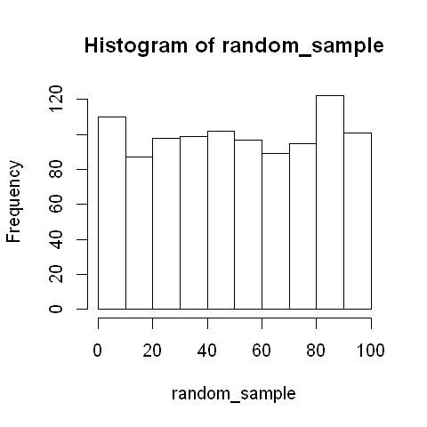

```r
random_sample<- sample (0:100,size=1000, replace=T) # sample from 0 to 100 a thousand times with replacement
hist (random_sample) # plot a histogram
```

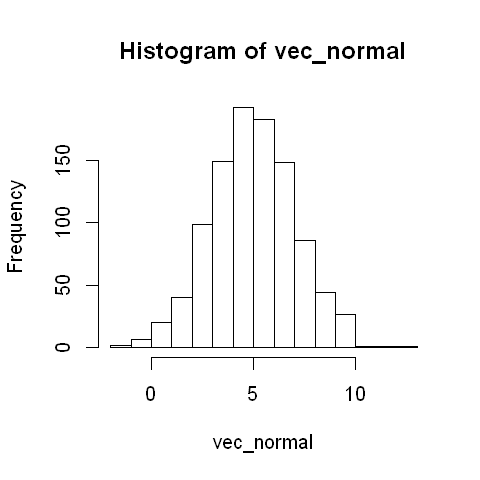

```r
vec_normal<-rnorm (1000,mean=5,sd=2) #normal distribution, 1000 N with mean 5 and SD=2
hist(vec_normal)
```

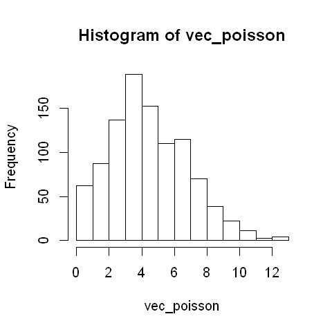

```r
vec_poisson<-rpois (1000, lambda=5) # poisson distribution, 1000 N with lambda=5
hist (vec_poisson)
```

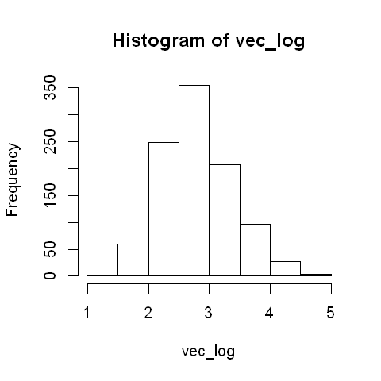

```r
vec_log<-rlnorm(1000, meanlog = 1, sdlog = 0.2) # log normal distribution
hist (vec_log)
```

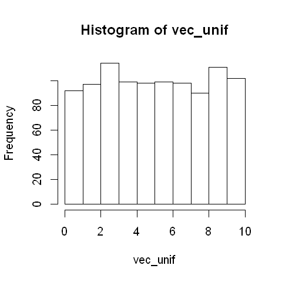

```r
vec_unif<-runif(1000,min=0,max=10)#1000 values varying from 0 to 10 – unif distribution
hist(vec_unif)
```

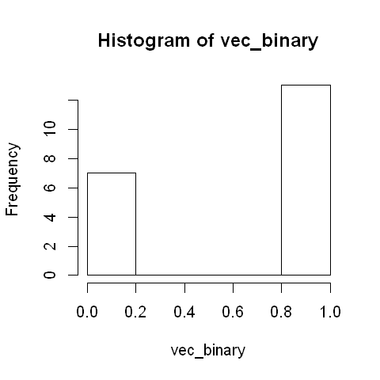

```r
vec_binary <- rbinom(20, 1, 0.5) # vector based on a random binomial generator
hist (vec_binary)
```

The function summary provide a fast summary of the values in your vector.

```r
summary (vec_normal)
```

```
   Min. 1st Qu.  Median    Mean 3rd Qu.    Max.
 -1.506   3.477   4.974   4.972   6.433  12.279
```

Return to the Summary

### Operations with vectors

Mathematical operations and functions can be easily applied to numerical vectors, for instance:

```r
vec_a <- seq(1,50,10)
vec_b <- rep (10,5)
vec_c <- vec_a + vec_b

print (vec_c)
```

```
[1] 11 21 31 41 51
```

```r
log_vec <- log10 (vec_c) #log (base 10) of each element present in the vector "vec_c"
print (log_vec)
```

```
[1] 1.041393 1.322219 1.491362 1.612784 1.707570
```

```r
median (vec_c) #median of the vector "vec_c"
```

31

```r
var (vec_c) # variance of the vector "vec_c"
```

250

You can also sort your vector and replace specific number or elements, for example:

```r
set.seed (1) # creating simulations or random objects that can be reproduced
random_sample <- sample(0:10,size=10,replace=F)

print (random_sample)
```

```
 [1]  8  3  6  0  1  4  2 10  9  7
```

```r
random_sample <-sort(random_sample,decreasing=T)#sorting the vector, from large to small numbers
print (random_sample)
```

```
 [1] 10  9  8  7  6  4  3  2  1  0
```

Let’s say that we want to replace the number 10 with the number 11

```r
random_sample [1] <- 11 #replace a specific element of the vector (OPTION 1)
print (random_sample)
```

```
 [1] 11  9  8  7  6  4  3  2  1  0
```

```r
set.seed(1)
random_sample <- sample(0:10,size=10,replace=F) # re-creating the original vector
random_sample <-ifelse(random_sample == 10,11, random_sample) # if the value is 10 replace with 11, else keep the original number. (OPTION 2)

print (sort (random_sample, decreasing=T))
```

```
 [1] 11  9  8  7  6  4  3  2  1  0
```

Return to the Summary

### Creating tables, matrices and dataframes

Matrices and dataframes are a group of vectors arranged in different rows and/or columns.  
The main difference between these classes is that matrices accept just a single type of vectors at a time (characters or numeric, for instance), while dataframes may be composed of different types of vectors. Let’s create a matrix and a dataframe based on multiple vectors.

```r
a <- rnorm (5, mean=2, sd=3)
b <- rnorm (5, mean=2, sd=3)
c <- rnorm (5, mean=2, sd=3)
cbind (a,b,c) # combine R objects by columns. This is a matrix.
```

| a | b | c |
| --- | --- | --- |
| 4.9764811 | 3.6822383 | -2.691346 |
| 0.7114607 | 0.6416481 | 5.469611 |
| 5.7149123 | -0.4961299 | 4.496141 |
| 1.1619612 | -1.4997116 | 1.318014 |
| 7.2737093 | -1.1967717 | 2.798412 |

```r
rbind (a,b,c) # combine R objects by rows. This is also a matrix.
```

| a | 4.976481 | 0.7114607 | 5.7149123 | 1.161961 | 7.273709 |
| --- | --- | --- | --- | --- | --- |
| b | 3.682238 | 0.6416481 | -0.4961299 | -1.499712 | -1.196772 |
| c | -2.691346 | 5.4696110 | 4.4961414 | 1.318014 | 2.798412 |

```r
summary (rbind (a,b,c)) # Matrices are composed of columns of the same type (in this case, numeric).
```

```
       V1                V2               V3                V4
 Min.   :-2.6913   Min.   :0.6416   Min.   :-0.4961   Min.   :-1.4997
 1st Qu.: 0.4954   1st Qu.:0.6766   1st Qu.: 2.0000   1st Qu.:-0.1689
 Median : 3.6822   Median :0.7115   Median : 4.4961   Median : 1.1620
 Mean   : 1.9891   Mean   :2.2742   Mean   : 3.2383   Mean   : 0.3268
 3rd Qu.: 4.3294   3rd Qu.:3.0905   3rd Qu.: 5.1055   3rd Qu.: 1.2400
 Max.   : 4.9765   Max.   :5.4696   Max.   : 5.7149   Max.   : 1.3180
       V5
 Min.   :-1.1968
 1st Qu.: 0.8008
 Median : 2.7984
 Mean   : 2.9585
 3rd Qu.: 5.0361
 Max.   : 7.2737
```

```r
d <- factor ( c(rep ("Cat_1",5),
                rep ("Cat_2",5)))

df_abcd <- cbind.data.frame (a,b,c,d) #creating a data frame.
summary (df_abcd) #Data frame accept columns with different types of variables (in this case, numeric and categorical/factor)
```

```
       a                b                 c              d
 Min.   :0.7115   Min.   :-1.4997   Min.   :-2.691   Cat_1:5
 1st Qu.:1.1620   1st Qu.:-1.1968   1st Qu.: 1.318   Cat_2:5
 Median :4.9765   Median :-0.4961   Median : 2.798
 Mean   :3.9677   Mean   : 0.2263   Mean   : 2.278
 3rd Qu.:5.7149   3rd Qu.: 0.6416   3rd Qu.: 4.496
 Max.   :7.2737   Max.   : 3.6822   Max.   : 5.470
```

Sometimes is useful to create empty matrices and dataframes, such the ones below.

```r
empty_matrix <- matrix (ncol=5,nrow=3)
empty_matrix
```

| NA | NA | NA | NA | NA |
| --- | --- | --- | --- | --- |
| NA | NA | NA | NA | NA |
| NA | NA | NA | NA | NA |

```r
as.data.frame (empty_matrix) # converting matrix into data frame
```

| V1 | V2 | V3 | V4 | V5 |
| --- | --- | --- | --- | --- |
| NA | NA | NA | NA | NA |
| NA | NA | NA | NA | NA |
| NA | NA | NA | NA | NA |

Finally, let's create a matrix and a dataframe with data, column name, and row names.

```r
matrix(1:9, nrow = 3, byrow=TRUE,
       dimnames = list(c("X","Y","Z"),
                       c("A","B","C"))) # fill matrix row-wise
```

|  | A | B | C |
| --- | --- | --- | --- |
| X | 1 | 2 | 3 |
| Y | 4 | 5 | 6 |
| Z | 7 | 8 | 9 |

```r
data.frame (A = c(1,2,3),
            B = c("red","blue","green"),
            C = c(5,4,3),
            row.names = c("X", "Y", "Z"))
```

|  | A | B | C |
| --- | --- | --- | --- |
| X | 1 | red | 5 |
| Y | 2 | blue | 4 |
| Z | 3 | green | 3 |

Return to the Summary

### Importing and exporting data with R

Most of the time, you will work with spreadsheets created in different programs, such as Excel. So, it is essential that you know how to import data to R. Besides that, in many situations, you have to export the result of analyses conducted in R to other programs. Below, you can find some examples about how to do it. The best way to import data into R is using a txt file or a csv file (Excel). To transform a xlsx file (defaut format of excel) into a csv file or a txt file, you have to: open the excel file > click on the “file” tab > click on save as > in the option “Save as type”, change “xlsx” to “CSV (Comma delimited) (*.csv)” or “Text (Tab delimited) (*.txt)”. Please transform the file “earth_worm.xlsx“ to csv and txt. Keep the same file name (“earth_worm.csv” and “earth_worm.txt”). Double check that all files were saved in the current directory (same folder where the R project was saved). Now, follow the steps below.

```r
earth_worm <- read.csv ("earth_worm.csv", header=T, sep=";") # header=T means header is present, “sep” the field separator character.
earth_worm <- read.table ("earth_worm.txt", header=T)
```

If your file is not in the current R directory, you can search for the file in your computer using the code below.

```r
earth_worm <- read.table(file.choose(), header=TRUE)
```

You can also import the data using CTRL+C with the auxiliary of the function clipboard. See below.

```r
#first copy (CTRL+C) the table and then run the code below
earth_worm <- read.table(file = "clipboard", sep = "", header=TRUE)
```

To export a dataframe or a matrix from R to a "txt" or "csv" file, you can use:

```r
write.table (earth_worm,file="earth_worm2.csv", sep=",") #csv
write.table (earth_worm,file="earth_worm2.txt", sep=",") #txt
```

Return to the Summary

### Visualizing dataframes

We can take a look at the dataframe using the function “View” or just clicking on the name of the object located in the workspace window.

```r
earth_worm <- read.csv ("earth_worm.csv", header=T, sep=";")
View (earth_worm)
# It doesn't work in the IDE that I'm using (Jupyter notebooks),
# but I promise that it works in R studio.
```

```
Error in View(earth_worm): 'View()' not yet supported in the Jupyter R kernel
Traceback:

1. View(earth_worm)
2. stop(sQuote("View()"), " not yet supported in the Jupyter R kernel")
```

You can also take a quick look at the first rows of the dataframe using the function "head".

```r
head (earth_worm)
```

| site | density | area | slope | pH.soil | soaked | vegetacao |
| --- | --- | --- | --- | --- | --- | --- |
| A | 4.2 | 3.6 | 11 | 4.1 | no | Grassland |
| A | 7.1 | 5.1 | 2 | 5.2 | yes | Arable |
| A | 2.5 | 2.8 | 3 | 4.3 | no | Grassland |
| A | 5.2 | 2.4 | 5 | 4.9 | yes | Meadow |
| A | 6.2 | 3.8 | 0 | 4.2 | no | Scrub |
| A | 2.0 | 3.1 | 2 | 3.9 | yes | Grassland |

The function "summary" provide us important information for each column of the dataframe, including number of observations per level for categorical variables and the median, mean, minimum, maximum, 1st and 3rd quartile for continuous variables.

```r
summary(earth_worm)
```

```
 site      density           area           slope          pH.soil
 A:10   Min.   : 0.00   Min.   :0.800   Min.   : 0.00   Min.   :3.500
 B:10   1st Qu.: 2.40   1st Qu.:2.175   1st Qu.: 0.75   1st Qu.:4.100
        Median : 4.70   Median :3.000   Median : 2.00   Median :4.600
        Mean   : 6.55   Mean   :2.990   Mean   : 3.50   Mean   :4.555
        3rd Qu.: 7.30   3rd Qu.:3.725   3rd Qu.: 5.25   3rd Qu.:5.000
        Max.   :42.00   Max.   :5.100   Max.   :11.00   Max.   :5.700
 soaked       vegetacao
 no :10   Arable   :3
 yes:10   Grassland:9
          Meadow   :3
          Orchard  :1
          Scrub    :4
```

How many columns and rows are present in this dataframe? Check with the code below or just take a look at the object in the workspace window.

```r
dim (earth_worm) # number of rows and columns, respectively.
```

1. 20

2. 7

```r
nrow (earth_worm) # number of rows
```

20

```r
ncol (earth_worm) # number of columns
```

7

It is easy to explore columns, rows or even single elements of a dataframe. You just need to specify the number of columns and the number of rows that you interest in. See the example below.

```r
earth_worm [1,2] #Access the element located in the first row of the second column.
```

4.2

```r
earth_worm [1:5,2] # Access the first five rows of the second column.
```

1. 4.2

2. 7.1

3. 2.5

4. 5.2

5. 6.2

```r
earth_worm [1:2,1:3] # Access the first two rows of the first, second and third column
```

| site | density | area |
| --- | --- | --- |
| A | 4.2 | 3.6 |
| A | 7.1 | 5.1 |

```r
print (earth_worm [,1]) #Display all rows of the first column. Blank space mean all.
```

```
 [1] A A A A A A A A A A B B B B B B B B B B
Levels: A B
```

```r
earth_worm [1,] #Display the first row of all columns. Blank space mean all.
```

| site | density | area | slope | pH.soil | soaked | vegetacao |
| --- | --- | --- | --- | --- | --- | --- |
| A | 4.2 | 3.6 | 11 | 4.1 | no | Grassland |

You can also access the columns of a dataframe using dollar symbol($) followed by the name of the variable. For example:

```r
print (earth_worm$site)
```

```
 [1] A A A A A A A A A A B B B B B B B B B B
Levels: A B
```

```r
earth_worm$area [1] #First element of the variable "area"
```

3.6

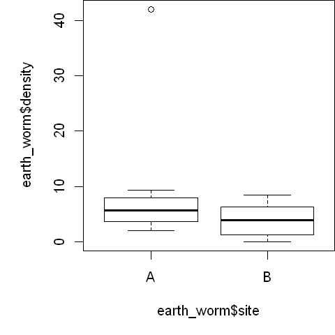

```r
plot (earth_worm$density~earth_worm$site)
# Boxplot to explore the density of earth worm between sites
```

Return to the Summary

### Operations with dataframes

Imagine that we want to replace the names of the columns. How can we do that?

```r
earth_worm <- read.csv ("earth_worm.csv", header=T, sep=";")
colnames (earth_worm) <- c("site","density","area","slope","ph.soil","soaked","vegetation")
```

You can also replace the name of specific columns.

```r
colnames (earth_worm)[5]<-"ph.soil" #replacing the name of the fifth column
```

Row names can also be edited in a similar way. Let’s do it!

```r
rownames (earth_worm) <- letters [1:nrow(earth_worm)] # you can use numbers, letters and names
head(earth_worm,3) # just the first three rows.
```

|  | site | density | area | slope | ph.soil | soaked | vegetation |
| --- | --- | --- | --- | --- | --- | --- | --- |
| a | A | 4.2 | 3.6 | 11 | 4.1 | no | Grassland |
| b | A | 7.1 | 5.1 | 2 | 5.2 | yes | Arable |
| c | A | 2.5 | 2.8 | 3 | 4.3 | no | Grassland |

```r
rownames (earth_worm)[1] <- "a"
```

Can we transform the row names into a column? Yes, we can!

```r
require(tibble) # the function that we will use require the package dplyr
earth_worm <- rownames_to_column(earth_worm, "New_column")
head (earth_worm)
```

A data.frame: 6 × 8

[output not shown]

Now, let’s remove the column "New_column" from the dataframe.

```r
earth_worm$New_column <-NULL
head(earth_worm,3)
```

| site | density | area | slope | ph.soil | soaked | vegetation |
| --- | --- | --- | --- | --- | --- | --- |
| A | 4.2 | 3.6 | 11 | 4.1 | no | Grassland |
| A | 7.1 | 5.1 | 2 | 5.2 | yes | Arable |
| A | 2.5 | 2.8 | 3 | 4.3 | no | Grassland |

Let’s log transform the variable density of the dataframe "earth_worm" and save with another name in the same dataframe.

```r
earth_worm$density_log <- log (earth_worm$density)
tail (earth_worm,3) # see the last three rows of the data frame
```

|  | site | density | area | slope | ph.soil | soaked | vegetation | density_log |
| --- | --- | --- | --- | --- | --- | --- | --- | --- |
| 18 | B | 5.4 | 4.4 | 2 | 4.5 | no | Arable | 1.6863990 |
| 19 | B | 1.3 | 2.9 | 1 | 3.5 | no | Grassland | 0.2623643 |
| 20 | B | 3.6 | 0.8 | 10 | 5.1 | yes | Scrub | 1.2809338 |

Another way to do the same thing is using the function within, for instance:

```r
earth_worm <- within (earth_worm, {
    density_log <- log1p (density) # you can make multiple operations at the same time. All
    soaked <- factor (soaked) # of them will be saved in the same object (earth_worm)
    vegetation <- factor (vegetation)
})
```

We can calculate the mean and sum of columns and rows using the functions below.

```r
sum_rows <- rowSums (earth_worm[,2:5])
# sum cannot be applied to categories, so we are just using the numeric columns

print (sum_rows)
```

```
 [1] 22.9 19.4 12.6 17.5 14.2 11.0 14.4 48.9 16.9 18.4 26.3  9.7 11.8 11.6 15.4
[16] 17.3 19.1 16.3  8.7 19.5
```

```r
sum_col <- colSums (earth_worm[,2:5])
print (sum_col)
```

```
density    area   slope ph.soil
  131.0    59.8    70.0    91.1
```

```r
mean_row <- rowMeans(earth_worm[,2:5])
print (mean_row)
```

```
 [1]  5.725  4.850  3.150  4.375  3.550  2.750  3.600 12.225  4.225  4.600
[11]  6.575  2.425  2.950  2.900  3.850  4.325  4.775  4.075  2.175  4.875
```

```r
mean_col <- colMeans (earth_worm[,2:5])
print (mean_col)
```

```
density    area   slope ph.soil
  6.550   2.990   3.500   4.555
```

Suppose that we are interested in the average of earth worms of each vegetation. To explore that, we can use the function "aggregate".

```r
aggregate (density~vegetation+soaked,
           FUN=mean, data=earth_worm)
#calculate the density mean by vegetation and by the variable soaked
```

| vegetation | soaked | density |
| --- | --- | --- |
| Arable | no | 23.700000 |
| Grassland | no | 2.166667 |
| Scrub | no | 7.200000 |
| Arable | yes | 7.100000 |
| Grassland | yes | 4.000000 |
| Meadow | yes | 6.666667 |
| Orchard | yes | 9.300000 |
| Scrub | yes | 3.900000 |

Using this function, we can summarize the data using multiple variables and even multiple functions.

```r
aggregate (cbind(density,density_log)~
           vegetation+soaked,FUN=mean, data=earth_worm) # Average more than one variable at a time
```

[output not shown]

```r
as.matrix(
    aggregate (density ~vegetation,
               FUN = function(x) c(mn = mean(x), sd = sd(x)),
               data=earth_worm)) # Use more than one function at a time
```

| vegetation | density.mn | density.sd |
| --- | --- | --- |
| Arable | 18.166667 | 20.657767 |
| Grassland | 2.777778 | 2.300423 |
| Meadow | 6.666667 | 1.680278 |
| Orchard | 9.300000 | NA |
| Scrub | 5.550000 | 2.087263 |

```r
as.matrix(
    aggregate (cbind (density,density_log) ~ vegetation + soaked,
               FUN = function(x) c(mn = mean(x), sd = sd(x)),
               data=earth_worm)) # Use more than one function and variable at a time
```

| vegetation | soaked | density.mn | density.sd | density_log.mn | density_log.sd |
| --- | --- | --- | --- | --- | --- |
| Arable | no | 23.7000000 | 25.8801082 | 2.7120343 | 1.4504674 |
| Grassland | no | 2.1666667 | 1.5995833 | -Inf | NA |
| Scrub | no | 7.2000000 | 1.4142136 | 1.9643417 | 0.1976964 |
| Arable | yes | 7.1000000 | NA | 1.9600948 | NA |
| Grassland | yes | 4.0000000 | 3.3778692 | 1.1673158 | 0.7794124 |
| Meadow | yes | 6.6666667 | 1.6802778 | 1.8764248 | 0.2476603 |
| Orchard | yes | 9.3000000 | NA | 2.2300144 | NA |
| Scrub | yes | 3.9000000 | 0.4242641 | 1.3580092 | 0.1090010 |

Logical operations are used to select data from a dataframe. For instance:

```r
earth_worm [earth_worm$soaked=="yes",] #select just areas where the soil is soaked
```

[output not shown]

```r
earth_worm [earth_worm$soaked!="yes",] #select just areas where the soil is NOT soaked
```

|  | site | density | area | slope | ph.soil | soaked | vegetation | density_log |
| --- | --- | --- | --- | --- | --- | --- | --- | --- |
| 1 | A | 4.2 | 3.6 | 11 | 4.1 | no | Grassland | 1.4350845 |
| 3 | A | 2.5 | 2.8 | 3 | 4.3 | no | Grassland | 0.9162907 |
| 5 | A | 6.2 | 3.8 | 0 | 4.2 | no | Scrub | 1.8245493 |
| 7 | A | 3.7 | 3.5 | 3 | 4.2 | no | Grassland | 1.3083328 |
| 8 | A | 42.0 | 2.1 | 0 | 4.8 | no | Arable | 3.7376696 |
| 11 | B | 8.2 | 2.9 | 10 | 5.2 | no | Scrub | 2.1041342 |
| 12 | B | 1.3 | 3.3 | 1 | 4.1 | no | Grassland | 0.2623643 |
| 14 | B | 0.0 | 1.8 | 6 | 3.8 | no | Grassland | -Inf |
| 18 | B | 5.4 | 4.4 | 2 | 4.5 | no | Arable | 1.6863990 |
| 19 | B | 1.3 | 2.9 | 1 | 3.5 | no | Grassland | 0.2623643 |

```r
earth_worm [earth_worm$soaked=="yes" & earth_worm$density>5,]
#select just areas where the soil is soaked and has a density higher than 5
```

|  | site | density | area | slope | ph.soil | soaked | vegetation | density_log |
| --- | --- | --- | --- | --- | --- | --- | --- | --- |
| 2 | A | 7.1 | 5.1 | 2 | 5.2 | yes | Arable | 1.960095 |
| 4 | A | 5.2 | 2.4 | 5 | 4.9 | yes | Meadow | 1.648659 |
| 9 | A | 9.3 | 1.9 | 0 | 5.7 | yes | Orchard | 2.230014 |
| 10 | A | 7.9 | 1.5 | 4 | 5.0 | yes | Grassland | 2.066863 |
| 15 | B | 6.3 | 4.1 | 0 | 5.0 | yes | Meadow | 1.840550 |
| 16 | B | 8.5 | 3.9 | 0 | 4.9 | yes | Meadow | 2.140066 |

The function subset is also very used to select data from a dataframe.

```r
subset (earth_worm, soaked=="yes" & density >5)
```

|  | site | density | area | slope | ph.soil | soaked | vegetation | density_log |
| --- | --- | --- | --- | --- | --- | --- | --- | --- |
| 2 | A | 7.1 | 5.1 | 2 | 5.2 | yes | Arable | 1.960095 |
| 4 | A | 5.2 | 2.4 | 5 | 4.9 | yes | Meadow | 1.648659 |
| 9 | A | 9.3 | 1.9 | 0 | 5.7 | yes | Orchard | 2.230014 |
| 10 | A | 7.9 | 1.5 | 4 | 5.0 | yes | Grassland | 2.066863 |
| 15 | B | 6.3 | 4.1 | 0 | 5.0 | yes | Meadow | 1.840550 |
| 16 | B | 8.5 | 3.9 | 0 | 4.9 | yes | Meadow | 2.140066 |

Two columns can be merged into one using the function “interaction”. See below.

```r
#Merge the variables soaked and vegetation into a column called soaked_vegatation
earth_worm$soaked_vegetation <- interaction (earth_worm$soaked, earth_worm$vegetation)
head (earth_worm, 3)
```

| site | density | area | slope | ph.soil | soaked | vegetation | density_log | soaked_vegetation |
| --- | --- | --- | --- | --- | --- | --- | --- | --- |
| A | 4.2 | 3.6 | 11 | 4.1 | no | Grassland | 1.4350845 | no.Grassland |
| A | 7.1 | 5.1 | 2 | 5.2 | yes | Arable | 1.9600948 | yes.Arable |
| A | 2.5 | 2.8 | 3 | 4.3 | no | Grassland | 0.9162907 | no.Grassland |

To split one column into two is not hard. Just follow the example below.

```r
new_data <- data.frame( do.call('rbind',
                                strsplit(
                                    as.character(earth_worm$soaked_vegetation),
                                    '.', fixed=TRUE)))
#as.character – makes sure that the variable is treated as a character
#strsplit - Split the elements of a character vector x into substrings. The second argument (‘.’) tells R where we want to split the character.
#do.call and data.frame are just used here to construct the dataframe.
head (new_data, 2)
```

| X1 | X2 |
| --- | --- |
| no | Grassland |
| yes | Arable |

Another very useful function is “merge” and is used to merge different dataframes.

```r
fish_morpho <- read.csv ("fish_morpho.csv",header=T,sep=";")
head (fish_morpho,2)
```

| Species | standard_length | Body_depth | Body.width |
| --- | --- | --- | --- |
| Acestrorhynchus_minimus | 49.84167 | 0.1372983 | 0.1012335 |
| Aequidens_tetramerus | 97.25000 | 0.5216407 | 0.2568074 |

```r
fish_diet <-read.csv ("fish_diet.csv",header=T,sep=";")
head (fish_diet,2)
```

| Species | Fish | Invertebrates | Plants |
| --- | --- | --- | --- |
| Astyanax_fasciatus | 1 | 1 | 1 |
| Acestrorhynchus_minimus | 1 | 0 | 0 |

```r
# By default the data frames are merged on the columns with names they both have.
fish_morpho_diet <-merge (fish_morpho, fish_diet, by="Species")
head (fish_morpho_diet,2)
```

| Species | standard_length | Body_depth | Body.width | Fish | Invertebrates | Plants |
| --- | --- | --- | --- | --- | --- | --- |
| Acestrorhynchus_minimus | 49.84167 | 0.1372983 | 0.1012335 | 1 | 0 | 0 |
| Aequidens_tetramerus | 97.25000 | 0.5216407 | 0.2568074 | 0 | 1 | 0 |

Sometimes, we want to re-order the whole dataframe in order to analyze data. Let’s suppose that we have a dataframe, where each row is an individual in a given habitat. For instance:

```r
grassland_forest <- read.csv("grassland_forest.csv",header=T,sep=";")
head (grassland_forest)
```

A data.frame: 6 × 4

|  | Habitat <chr> | Species <chr> | Individual <int> | Size <int> |
| --- | --- | --- | --- | --- |
| 1 | Grassland | Species A | 1 | 10 |
| 2 | Grassland | Species A | 2 | 15 |
| 3 | Grassland | Species A | 3 | 20 |
| 4 | Grassland | Species A | 4 | 13 |
| 5 | Grassland | Species A | 5 | 12 |
| 6 | Grassland | Species A | 6 | 19 |

The dataframe looks OK, but what we want is to create a site-species matrix to explore changes in species abundance among the sites. How can we do that? The function “dcast” of the package “reshape2” is very useful to do these kind of tasks, saving us a lot of time. See below.

```r
require (reshape2)

grassland_forest_pivoted <- dcast (grassland_forest, Habitat~Species, length)
# first argument is the data, the second is a formula (in this case, habitat will be the rows and species the columns),
# the third is the function to be applied (here we used “length”, which count the number of rows==individuals)

head (grassland_forest_pivoted)
```

A data.frame: 2 × 3

|  | Habitat <chr> | Species A <int> | Species B <int> |
| --- | --- | --- | --- |
| 1 | Forest | 6 | 12 |
| 2 | Grassland | 13 | 16 |

Before we finish, let’s create another site-species matrix, but this time instead of abundance we will use mean size.

```r
grassland_forest_pivoted <- dcast (grassland_forest, Habitat ~ Species, value="Size", mean)
#the argument “value” is use here to ensure that the function “dcast” is calculating the mean using the variable “size”.

head (grassland_forest_pivoted)
```

| Habitat | Species A | Species B |
| --- | --- | --- |
| Forest | 17.00000 | 17.41667 |
| Grassland | 14.46154 | 11.62500 |

Return to the Summary

## Plots

### Scatterplots

The first type of graphs that we are going to explore is scatterplots. These plots are usually used to show the relationship between two continuous variables. Each sampling unit (rows) are represented in the plot as a point. To create the scatterplots, let’s load the dataset "dispersion1".

```r
dispersion <- read.table ("dispersion1.txt",header=T)
names(dispersion) # the names of the columns are x and y
```

1. 'x'

2. 'y'

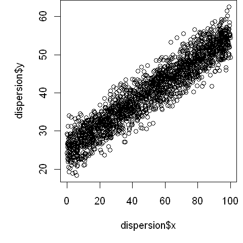

```r
par (mai=c(1,1,0,0.1)) #define margins of the figure
# use the help function to understand what these numbers really mean.

plot (dispersion$y ~ dispersion$x)
# plot (y~x, data = dispersion)     <----- Equivalent but using less code
```

To change the color of the points, we use the argument “col”. A list with the code for several different colors can be found in this link: http://www.stat.columbia.edu/~tzheng/files/Rcolor.pdf

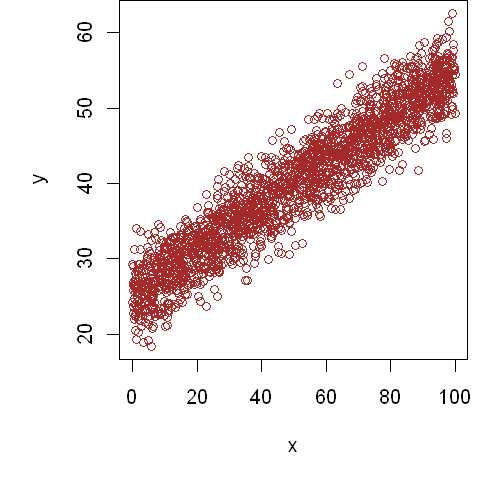

```r
par (mai=c(1,1,0,0.1))
plot (y~x, data=dispersion,
      col="brown")
```

The argument pch change the symbol of the object. The defaut symbol is an empty circle (code =1), but we can choose among several different types. The codification for each one of them can be seen below.

[figure not shown]

Source: https://www.statmethods.net/advgraphs/parameters.html

For this example, we are going to use the square symbol (code=0).

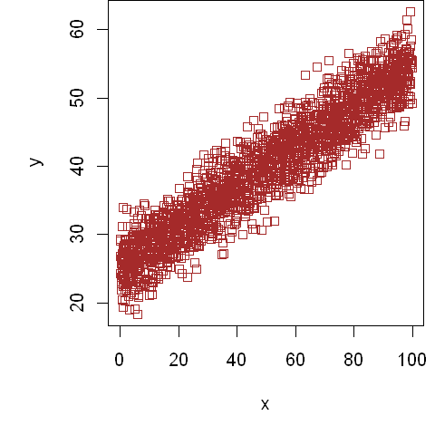

```r
par (mai=c(1,1,0,0.1))
plot (y~x, data= dispersion,
      col="brown", pch=0)
```

Now, let’s add a title for this figure using the argument "main".

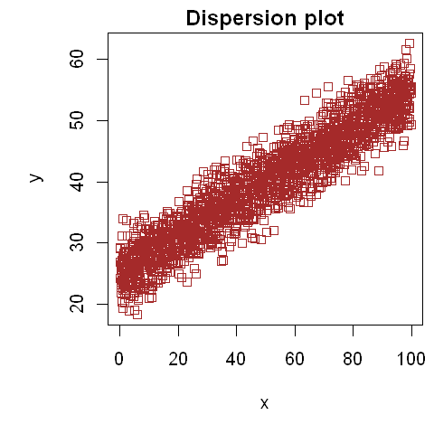

```r
par (mai=c(1,1,0.3,0.1))
plot (y~x, data= dispersion,
      col="brown", pch=0,
      main= "Dispersion plot")
```

We shouldn’t forget to edit the axes titles. This can be easily done using the arguments xlab and ylab.

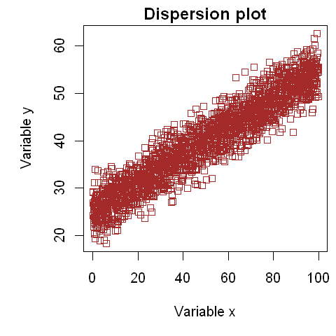

```r
par (mai=c(1,1,0.3,0.1))
plot (y~x, data= dispersion,
      col="brown", pch=0,
      main= "Dispersion plot",
      ylab= "Variable y",
      xlab= "Variable x")
```

The axes titles and labels look small. Let’s increase them using the arguments cex.lab and cex.axis, respectively. The symbol and title size can also be increased using the function cex and cex.main, respectively.

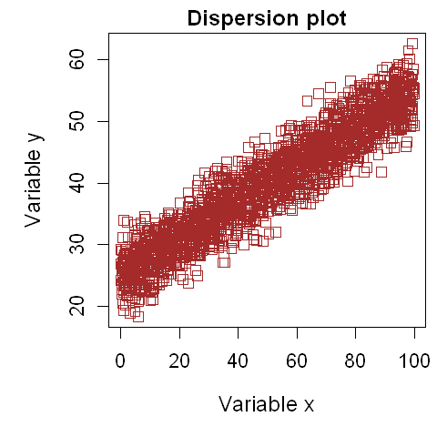

```r
par (mai=c(1,1,0.3,0.1))
plot (y~x, data= dispersion,
      col="brown", pch=0, cex=1.2,
      main= "Dispersion plot",
      ylab= "Variable y",
      xlab= "Variable x",
      cex.lab=1.2,cex.axis=1.1, cex.main=1.2)
```

We can also add more data into the figure using a different database. To do that, we can use the function “points”. For instance:

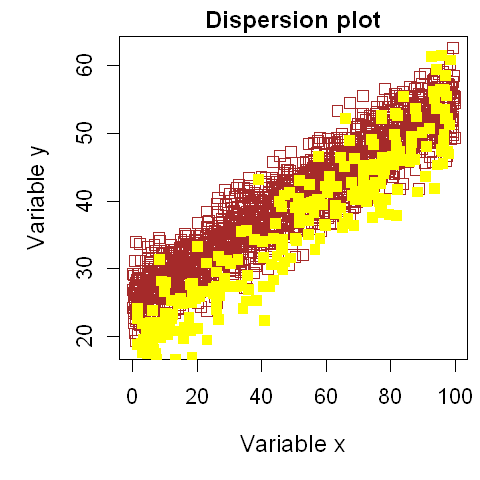

```r
dispersion2<-read.table("dispersion2.txt",header=T)

par (mai=c(1,1,0.3,0.1))
plot (y~x, data= dispersion,
      col="brown", pch=0, cex=1.2,
      main= "Dispersion plot",
      ylab= "Variable y",
      xlab= "Variable x",
      cex.lab=1.2,cex.axis=1.1, cex.main=1.2)
points (y~x,data= dispersion2, col="yellow",pch=15,cex=1.2)
```

That looks nice, but some points are overlapping with the boarders of the plot. We can fix this setting the limits for the y (ylim) and x (xlim) axes in the plot function. The x and y range for each dataset can be accessed using the function range.

```r
range(c(dispersion$y, dispersion$y)) #range of the variable y in both datasets
range(c(dispersion$x,dispersion2$x)) #range of the variable x in both datasets
```

1. 18.33571

2. 62.59482

1. 0.02849861

2. 99.93262

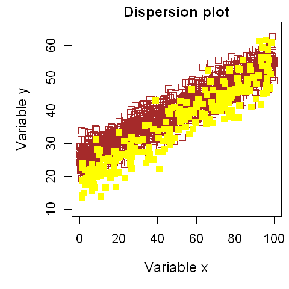

```r
par (mai=c(1,1,0.3,0.1))
plot (y~x, data= dispersion,
      col="brown", pch=0, cex=1.2,
      main= "Dispersion plot",
      ylab= "Variable y",
      xlab= "Variable x",
      cex.lab=1.2,cex.axis=1.1, cex.main=1.2,
      ylim= c(10,65), xlim= c(0,100))
points (y~x,data= dispersion2, col="yellow",pch=15,cex=1.2)
```

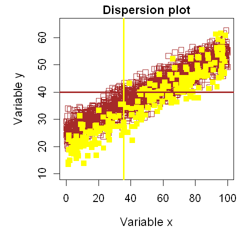

```r
par (mai=c(1,1,0.3,0.1))
plot (y~x, data= dispersion,
      col="brown", pch=0, cex=1.2,
      main= "Dispersion plot",
      ylab= "Variable y",
      xlab= "Variable x",
      cex.lab=1.2,cex.axis=1.1, cex.main=1.2,
      ylim= c(10,65), xlim= c(0,100))
points (y~x,data= dispersion2, col="yellow",pch=15,cex=1.2)

abline(h=mean(dispersion$y),
       col="brown",lty=1,lwd=3) # lty= Type of line # lwd = Width of the line
abline(v=mean(dispersion2$y),
       col="yellow",lty=1,lwd=3) # lty= Type of line # lwd = Width of the line

#To add a vertical line representing the mean of the axis x, you just have to
# substitute “h” with “v” and replace the variable “y” with the variable “x”.
```

We are still missing a legend, so let’s add it to the figure.

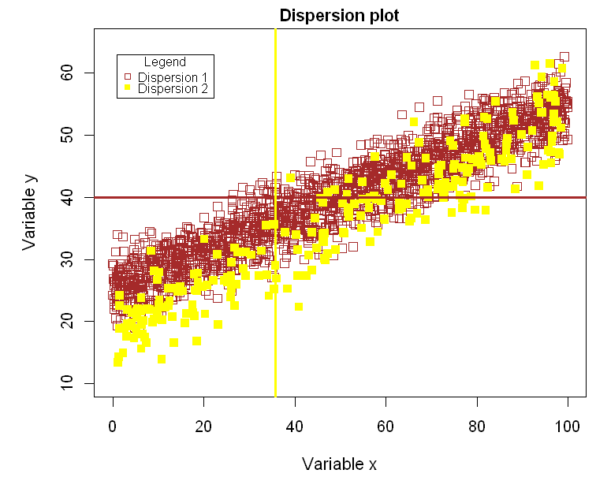

```r
par (mai=c(1,1,0.3,0.1))
plot (y~x, data= dispersion,
      col="brown", pch=0, cex=1.2,
      main= "Dispersion plot",
      ylab= "Variable y",
      xlab= "Variable x",
      cex.lab=1.1,cex.axis=1, cex.main=1.1,
      ylim= c(10,65), xlim= c(0,100))
points (y~x,data= dispersion2, col="yellow",pch=15,cex=1.2)

abline(h=mean(dispersion$y),
       col="brown",lty=1,lwd=3) # lty= Type of line # lwd = Width of the line
abline(v=mean(dispersion2$y),
       col="yellow",lty=1,lwd=3) # lty= Type of line # lwd = Width of the line
legend(1,63,c("Dispersion 1","Dispersion 2"),
       pch=c(0,15), col=c("brown","yellow"),
       title="Legend",cex=0.8,bty = "b")
# The number 1 and 63 are coordinates
#for the location of the legend in the figure. Bty is an argument related with
#the box around the legend. If you change it to "n", the box go away.
```

Done! Now, let’s export this figure with high quality. To do that, we use the function tiff.

```r
tiff(file="Scatter_plot.tiff",width=2000,height=2000,units = "px",
     compression="lzw",res=300)
par(mai=c(1,1,1,1)) # use the help function to understand what these numbers really mean.
plot (y~x, data= dispersion,
      col="brown", pch=0, cex=1.2,
      main= "Dispersion plot",
      ylab= "Variable y",
      xlab= "Variable x",
      cex.lab=1.2,cex.axis=1.1, cex.main=1.2,
      ylim= c(10,65), xlim= c(0,100))
points (y~x,data= dispersion2, col="yellow",pch=15,cex=1.2)

abline(h=mean(dispersion$y),
       col="brown",lty=1,lwd=3) # lty= Type of line # lwd = Width of the line
abline(v=mean(dispersion2$y),
       col="yellow",lty=1,lwd=3) # lty= Type of line # lwd = Width of the line
legend(1,63,c("Dispersion 1","Dispersion 2"),
       pch=c(0,15), col=c("brown","yellow"),
       title="Legend",cex=0.8,bty = "o")
#The number 1 and 63 are coordinates
#for the location of the legend in the figure. Bty is an argument related with
#the box around the legend. If you change to "n", the box go away
dev.off()
```

**png:** 2

Return to the Summary

### Boxplots

Boxplots are graphs that are used to explore the values of a continuous variable among different levels of a categorical variable. Central horizontal lines within the boxes are the median values; upper and lower hinges are the third and first quartiles, respectively; and whiskers indicate the maximum and minimum values. To explore this kind of graph, let’s load the file “ciano” into R.

```r
ciano <- read.table ("ciano.txt",header=T)
summary (ciano)
```

```
     toxin       block       temp    nutri
 Min.   : 60.0   A:18   control:36   N :24
 1st Qu.: 86.0   B:18   High   :36   NP:24
 Median : 96.5   C:18                P :24
 Mean   :100.6   D:18
 3rd Qu.:114.5
 Max.   :136.0
```

This data was taken from an experimental study that explored the addition effect of nutrients on the toxin production of cyanobacteria. The column "nutri" is categorical and contains three treatment levels: N addition, P addition, and N+P addition. The column “toxin” is composed of different values of toxin found in the water. Therefore, this variable is continuous and will be consider as our response. Let’s use the function plot to create the boxplot.

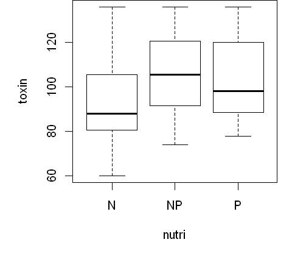

```r
par (mai=c(1,1,0,0.2))
plot (toxin~nutri, data=ciano)
```

The different levels of the category are placed in the plot according to their alphabetic order. To change the order, we can use the function “factor” and its argument “levels”. See below.

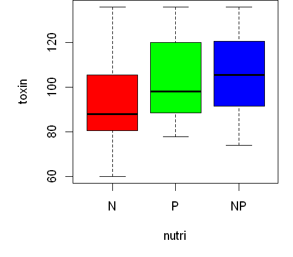

```r
par (mai=c(1,1,0,0.2))
ciano$nutri<-factor(ciano$nutri, levels =c("N","P","NP"))
plot (toxin~nutri, data=ciano,
     col=c("red","green","blue")) #define color for each box
```

Return to the Summary

### Barplots

Similar to boxplots, barplots are also used to show the variation of values of a continuous variable among the different levels of a categorical variable. Bars usually represent mean values and, in most cases, error bars (CI, SD, etc) are present in each bar to show the variation around the mean. First, we will create a dataset.

```r
sp1 <- c(12,15,13,14)
sp2 <-c(18,17,14,19)
sp3 <-c(10,11,13,8)
abund <-cbind(sp1,sp2,sp3)
```

Second, we will use the function barplot to plot the data.

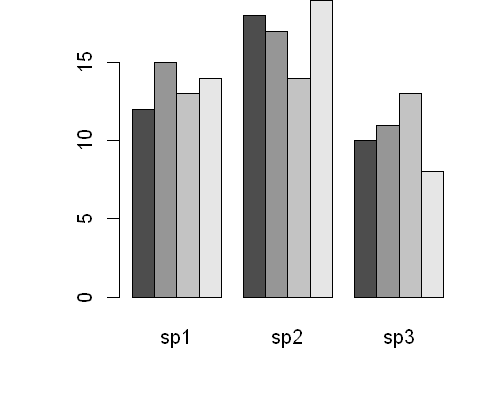

```r
par (mai=c(1,1,0,0.2))
barplot (abund, beside=T) # add legend using the legend
```

This plot shows us the raw numbers for each element of the vector. To show the mean and SD for each column, we will have to conduct some extra steps. First, we will create our own function that will return two things: the mean and the sd.

```r
mean_sd <- function(x) {
    c(Mean = mean(x), SD = sd (x))
}
```

The function that we just created has a single argument: “x”. This “x” is used to compute the mean and the SD. Easy, isn’t it? Now, let’s run our function and then plot the data.

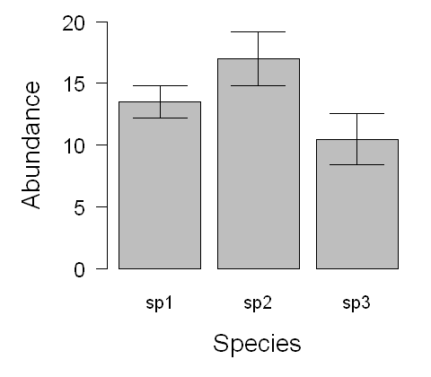

```r
abund<-as.data.frame(abund) #transforming matrix into a dataframe, otherwise the sapply function return some weird output.

summary_data <-sapply (abund, mean_sd) # this function allows you to run a function in each column of your dataframe.

plotTop <- round(max(summary_data[1,]+ summary_data[2,]), digit=-1)
#First we find the upper limit in our data (based on SE) and then we round the number (aesthetic detail)

names <- c("sp1","sp2","sp3")

par (mai=c(1,1,0.2,0.2))
barCenters <- barplot(summary_data[1,], names.arg=names, col="gray", las=1, ylim=c(0, plotTop),
                     ylab = "Abundance", xlab= "Species", cex.lab = 1.4, cex.axis = 1.2)

arrows(barCenters, summary_data[1,]- summary_data[2,], # coordinates of points from which to draw (x and y).
       barCenters, summary_data[1,]+ summary_data[2,], # coordinates of points to which to draw (x1 and y1).
       lwd=1, angle=90, code=3) # lwd= type of line, code= determining kind of arrows to be drawn
```

That looks good. You can export the figure if you want using the "tiff" function.

Return to the Summary

### Histograms and kernel density estimation plots

These two categories of plots are used to explore the distribution of numerical data. First, we create vectors with gaussian (normal) distribution.

```r
vec_normal <- rnorm (10000, mean=50,sd=10)
```

Now, we can plot the data using histograms and kernel density estimation plots

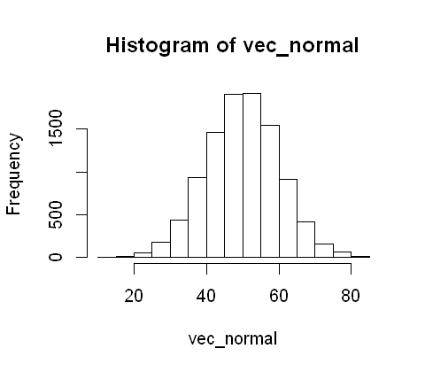

```r
hist (vec_normal)
```

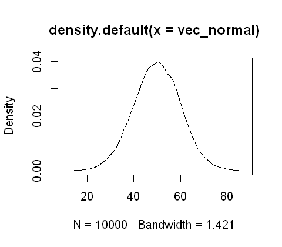

```r
plot(density (vec_normal))
```

Return to the Summary

### Pie charts

Although this category of plots is rarely used in scientific papers (at least, not in Ecology) we may want to use them in presentations.  
To create a pie chart is super easy. See below.

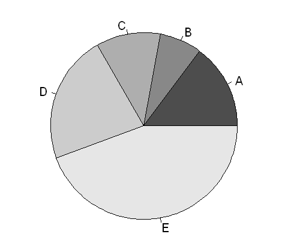

```r
values <- c(20,10,15,30,60)
lab <- c("A","B","C","D","E")

par (mai= c(0,0,0,0))
pie(values,
    labels=lab,
    col=gray.colors(5), # gray gradient
    cex= 1.0) # label size
```

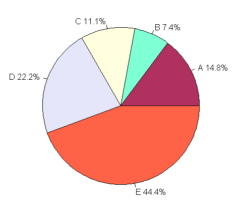

```r
percentages <- round (values/ sum(values), 3) *100
lab2 <- paste (lab," ", percentages, '%', sep="") # combine labels with the percentage

par (mai=c(0,0,0,0))
pie(values,
    col=c("maroon","aquamarine","lightyellow","lavender","tomato"),
    labels= lab2,
    cex= 0.8, # Label size
   )
```

Return to the Summary

### Plots to explore multicollinearity in the database

Multicollinearity, or simplify the high intercorrelations or inter-associations among the independent variables, is a major concern in many statistical tests. R has some nice ways to explore how variables are inter-correlated. Here, we are going to see the function “pairs”. First, let’s load the dataset “ozone” into R.

```r
ozone <-read.table("ozone.txt",header=T)
head (ozone,3)
```

| rad | temp | wind | ozone |
| --- | --- | --- | --- |
| 190 | 67 | 7.4 | 41 |
| 118 | 72 | 8.0 | 36 |
| 149 | 74 | 12.6 | 12 |

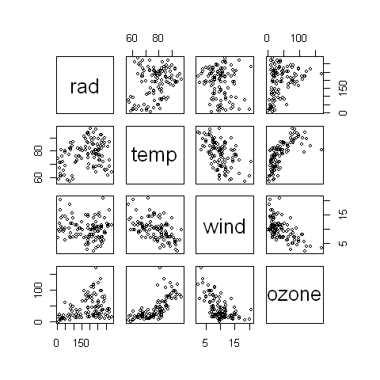

```r
par (mai=c(0.1,0.1,0,0))
pairs (ozone,cex=0.6)
```

Imagine that this data come from three different localities (37 observations in each one) and we are interested to see if these correlations are still consistent within each locality. To that, we create unique colors for each locality and plot the figure again.

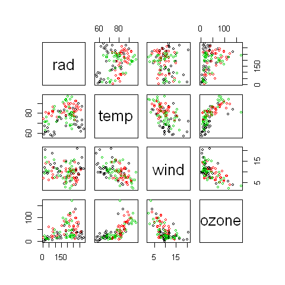

```r
par (mai=c(0.1,0.1,0,0))
pairs(ozone, cex =0.6,
      col= rep(c(1,2,3),
               each=37))
```

We can also add a trendline in each plot. For instance:

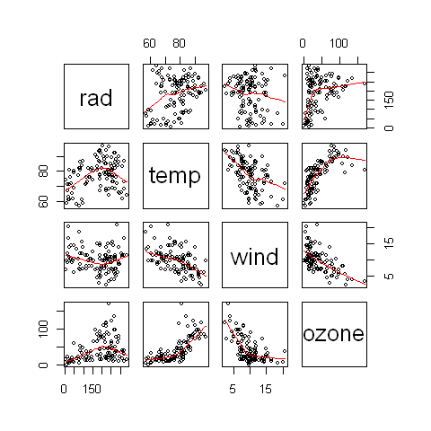

```r
par (mai=c(0.1,0.1,0,0))
pairs(ozone, panel=panel.smooth,
     cex=0.6)
```

If all the variables are continuous, you can also use the function "chart.Correlation" from the package PerformanceAnalytics. This package provides the correlation coefficients among variables as well as the histogram of each variable.

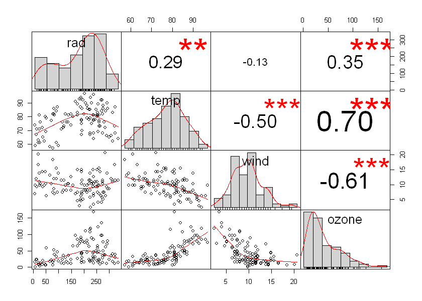

```r
require("PerformanceAnalytics")

par (mai=c(0,0,0,0))
chart.Correlation(ozone, histogram=TRUE, pch=19)
```

Another alternative is the function corrplot from the package corrplot

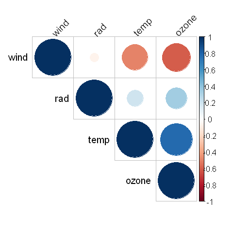

```r
require(corrplot)

cor_ozone <- cor(ozone, method = "spearman") #define correlation method
corrplot (cor_ozone, type = "upper", order = "hclust",
         tl.col = "black", tl.srt = 45)
```

Return to the Summary